# Project memo

Team Weather: Colin, Kailer, Jennifer

## Data Clean Up Steps for Overall Data

### Step 0: Load Libraries

```r
library(tidyverse)
library(broom)
library(lubridate)
library(RColorBrewer)
library(leaflet)
library(sf)
library(mapdata)
library(tigris)
```

### Step 1: Read Individual CSV Files

Our data came split into separate files by year. Here, we read each of these files, and remove the columns we do not plan on using. These are set to not run because the csv files are too large to easily push to GitHub, and Posit would frequently crash trying to read them.

```r
StormEvents_2010 <- read_csv("../data/ignore/StormEvents_details-ftp_v1.0_d2010_c20250520.csv")
StormEvents_2010 <- StormEvents_2010 |>
  filter(EVENT_TYPE %in% c("Avalanche","Blizzard","Drought","Flood","Flash Flood","Excessive Heat","Tornado","Tropical Storm","Tsunami","Wildfire"))

StormEvents_2010 <- StormEvents_2010 |>
  select(-CZ_TYPE,-CZ_NAME,-TOR_F_SCALE, -TOR_LENGTH,-TOR_WIDTH,-TOR_OTHER_WFO,-TOR_OTHER_CZ_STATE,-TOR_OTHER_CZ_FIPS,-TOR_OTHER_CZ_NAME,-BEGIN_RANGE,-BEGIN_AZIMUTH,-BEGIN_LOCATION,-END_RANGE,-END_AZIMUTH,-END_LOCATION,-EPISODE_NARRATIVE,-EVENT_NARRATIVE,-DATA_SOURCE,-WFO,-YEAR)
```

```r
StormEvents_2011 <- read_csv("../data/ignore/StormEvents_details-ftp_v1.0_d2011_c20250520.csv")
StormEvents_2011 <- StormEvents_2011 |>
  filter(EVENT_TYPE %in% c("Avalanche","Blizzard","Drought","Flood","Flash Flood","Excessive Heat","Tornado","Tropical Storm","Tsunami","Wildfire"))

StormEvents_2011 <- StormEvents_2011 |>
  select(-CZ_TYPE,-CZ_NAME,-TOR_F_SCALE, -TOR_LENGTH,-TOR_WIDTH,-TOR_OTHER_WFO,-TOR_OTHER_CZ_STATE,-TOR_OTHER_CZ_FIPS,-TOR_OTHER_CZ_NAME,-BEGIN_RANGE,-BEGIN_AZIMUTH,-BEGIN_LOCATION,-END_RANGE,-END_AZIMUTH,-END_LOCATION,-EPISODE_NARRATIVE,-EVENT_NARRATIVE,-DATA_SOURCE,-WFO,-YEAR)
```

```r
StormEvents_2012 <- read_csv("../data/ignore/StormEvents_details-ftp_v1.0_d2012_c20250520.csv")

StormEvents_2012 <- StormEvents_2012 |>
  filter(EVENT_TYPE %in% c("Avalanche","Blizzard","Drought","Flood","Flash Flood","Excessive Heat","Tornado","Tropical Storm","Tsunami","Wildfire"))

StormEvents_2012 <- StormEvents_2012 |>
  select(-CZ_TYPE,-CZ_NAME,-TOR_F_SCALE, -TOR_LENGTH,-TOR_WIDTH,-TOR_OTHER_WFO,-TOR_OTHER_CZ_STATE,-TOR_OTHER_CZ_FIPS,-TOR_OTHER_CZ_NAME,-BEGIN_RANGE,-BEGIN_AZIMUTH,-BEGIN_LOCATION,-END_RANGE,-END_AZIMUTH,-END_LOCATION,-EPISODE_NARRATIVE,-EVENT_NARRATIVE,-DATA_SOURCE,-WFO,-YEAR)
```

```r
StormEvents_2013 <- read_csv("../data/ignore/StormEvents_details-ftp_v1.0_d2013_c20250520.csv")

StormEvents_2013 <- StormEvents_2013 |>
  filter(EVENT_TYPE %in% c("Avalanche","Blizzard","Drought","Flood","Flash Flood","Excessive Heat","Tornado","Tropical Storm","Tsunami","Wildfire"))

StormEvents_2013 <- StormEvents_2013 |>
  select(-CZ_TYPE,-CZ_NAME,-TOR_F_SCALE, -TOR_LENGTH,-TOR_WIDTH,-TOR_OTHER_WFO,-TOR_OTHER_CZ_STATE,-TOR_OTHER_CZ_FIPS,-TOR_OTHER_CZ_NAME,-BEGIN_RANGE,-BEGIN_AZIMUTH,-BEGIN_LOCATION,-END_RANGE,-END_AZIMUTH,-END_LOCATION,-EPISODE_NARRATIVE,-EVENT_NARRATIVE,-DATA_SOURCE,-WFO,-YEAR)
```

```r
StormEvents_2014 <- read_csv("../data/ignore/StormEvents_details-ftp_v1.0_d2014_c20250520.csv")

StormEvents_2014 <- StormEvents_2014 |>
  filter(EVENT_TYPE %in% c("Avalanche","Blizzard","Drought","Flood","Flash Flood","Excessive Heat","Tornado","Tropical Storm","Tsunami","Wildfire"))

StormEvents_2014 <- StormEvents_2014 |>
  select(-CZ_TYPE,-CZ_NAME,-TOR_F_SCALE, -TOR_LENGTH,-TOR_WIDTH,-TOR_OTHER_WFO,-TOR_OTHER_CZ_STATE,-TOR_OTHER_CZ_FIPS,-TOR_OTHER_CZ_NAME,-BEGIN_RANGE,-BEGIN_AZIMUTH,-BEGIN_LOCATION,-END_RANGE,-END_AZIMUTH,-END_LOCATION,-EPISODE_NARRATIVE,-EVENT_NARRATIVE,-DATA_SOURCE,-WFO,-YEAR)
```

```r
StormEvents_2015 <- read_csv("../data/ignore/StormEvents_details-ftp_v1.0_d2015_c20250818.csv")

StormEvents_2015 <- StormEvents_2015 |>
  filter(EVENT_TYPE %in% c("Avalanche","Blizzard","Drought","Flood","Flash Flood","Excessive Heat","Tornado","Tropical Storm","Tsunami","Wildfire"))

StormEvents_2015 <- StormEvents_2015 |>
  select(-CZ_TYPE,-CZ_NAME,-TOR_F_SCALE, -TOR_LENGTH,-TOR_WIDTH,-TOR_OTHER_WFO,-TOR_OTHER_CZ_STATE,-TOR_OTHER_CZ_FIPS,-TOR_OTHER_CZ_NAME,-BEGIN_RANGE,-BEGIN_AZIMUTH,-BEGIN_LOCATION,-END_RANGE,-END_AZIMUTH,-END_LOCATION,-EPISODE_NARRATIVE,-EVENT_NARRATIVE,-DATA_SOURCE,-WFO,-YEAR)
```

```r
StormEvents_2016 <- read_csv("../data/ignore/StormEvents_details-ftp_v1.0_d2016_c20250818.csv")

StormEvents_2016 <- StormEvents_2016 |>
  filter(EVENT_TYPE %in% c("Avalanche","Blizzard","Drought","Flood","Flash Flood","Excessive Heat","Tornado","Tropical Storm","Tsunami","Wildfire"))

StormEvents_2016 <- StormEvents_2016 |>
  select(-CZ_TYPE,-CZ_NAME,-TOR_F_SCALE, -TOR_LENGTH,-TOR_WIDTH,-TOR_OTHER_WFO,-TOR_OTHER_CZ_STATE,-TOR_OTHER_CZ_FIPS,-TOR_OTHER_CZ_NAME,-BEGIN_RANGE,-BEGIN_AZIMUTH,-BEGIN_LOCATION,-END_RANGE,-END_AZIMUTH,-END_LOCATION,-EPISODE_NARRATIVE,-EVENT_NARRATIVE,-DATA_SOURCE,-WFO,-YEAR)
```

```r
StormEvents_2017 <- read_csv("../data/ignore/StormEvents_details-ftp_v1.0_d2017_c20250520.csv")

StormEvents_2017 <- StormEvents_2017 |>
  filter(EVENT_TYPE %in% c("Avalanche","Blizzard","Drought","Flood","Flash Flood","Excessive Heat","Tornado","Tropical Storm","Tsunami","Wildfire"))

StormEvents_2017 <- StormEvents_2017 |>
  select(-CZ_TYPE,-CZ_NAME,-TOR_F_SCALE, -TOR_LENGTH,-TOR_WIDTH,-TOR_OTHER_WFO,-TOR_OTHER_CZ_STATE,-TOR_OTHER_CZ_FIPS,-TOR_OTHER_CZ_NAME,-BEGIN_RANGE,-BEGIN_AZIMUTH,-BEGIN_LOCATION,-END_RANGE,-END_AZIMUTH,-END_LOCATION,-EPISODE_NARRATIVE,-EVENT_NARRATIVE,-DATA_SOURCE,-WFO,-YEAR)
```

```r
StormEvents_2018 <- read_csv("../data/ignore/StormEvents_details-ftp_v1.0_d2018_c20250520.csv")

StormEvents_2018 <- StormEvents_2018 |>
  filter(EVENT_TYPE %in% c("Avalanche","Blizzard","Drought","Flood","Flash Flood","Excessive Heat","Tornado","Tropical Storm","Tsunami","Wildfire"))

StormEvents_2018 <- StormEvents_2018 |>
  select(-CZ_TYPE,-CZ_NAME,-TOR_F_SCALE, -TOR_LENGTH,-TOR_WIDTH,-TOR_OTHER_WFO,-TOR_OTHER_CZ_STATE,-TOR_OTHER_CZ_FIPS,-TOR_OTHER_CZ_NAME,-BEGIN_RANGE,-BEGIN_AZIMUTH,-BEGIN_LOCATION,-END_RANGE,-END_AZIMUTH,-END_LOCATION,-EPISODE_NARRATIVE,-EVENT_NARRATIVE,-DATA_SOURCE,-WFO,-YEAR)
```

```r
StormEvents_2019 <- read_csv("../data/ignore/StormEvents_details-ftp_v1.0_d2019_c20250520.csv")

StormEvents_2019 <- StormEvents_2019 |>
  filter(EVENT_TYPE %in% c("Avalanche","Blizzard","Drought","Flood","Flash Flood","Excessive Heat","Tornado","Tropical Storm","Tsunami","Wildfire"))

StormEvents_2019 <- StormEvents_2019 |>
  select(-CZ_TYPE,-CZ_NAME,-TOR_F_SCALE, -TOR_LENGTH,-TOR_WIDTH,-TOR_OTHER_WFO,-TOR_OTHER_CZ_STATE,-TOR_OTHER_CZ_FIPS,-TOR_OTHER_CZ_NAME,-BEGIN_RANGE,-BEGIN_AZIMUTH,-BEGIN_LOCATION,-END_RANGE,-END_AZIMUTH,-END_LOCATION,-EPISODE_NARRATIVE,-EVENT_NARRATIVE,-DATA_SOURCE,-WFO,-YEAR)
```

```r
StormEvents_2020 <- read_csv("../data/ignore/StormEvents_details-ftp_v1.0_d2020_c20250702.csv")

StormEvents_2020 <- StormEvents_2020 |>
  filter(EVENT_TYPE %in% c("Avalanche","Blizzard","Drought","Flood","Flash Flood","Excessive Heat","Tornado","Tropical Storm","Tsunami","Wildfire"))

StormEvents_2020 <- StormEvents_2020 |>
  select(-CZ_TYPE,-CZ_NAME,-TOR_F_SCALE, -TOR_LENGTH,-TOR_WIDTH,-TOR_OTHER_WFO,-TOR_OTHER_CZ_STATE,-TOR_OTHER_CZ_FIPS,-TOR_OTHER_CZ_NAME,-BEGIN_RANGE,-BEGIN_AZIMUTH,-BEGIN_LOCATION,-END_RANGE,-END_AZIMUTH,-END_LOCATION,-EPISODE_NARRATIVE,-EVENT_NARRATIVE,-DATA_SOURCE,-WFO,-YEAR)
```

### Step 2: Combine into one CSV file

Next, we took all these individual CSVs and combined them into one. This is also set to not run since the original CSVs are not loaded.

```r
storms <- rbind(StormEvents_2010,
                StormEvents_2011,
                StormEvents_2012,
                StormEvents_2013,
                StormEvents_2014,
                StormEvents_2015,
                StormEvents_2016,
                StormEvents_2017,
                StormEvents_2018,
                StormEvents_2019,
                StormEvents_2020)
write_csv(storms, file="../data/storms2.csv")
```

```r
# reload CSV because above chunks are eval=FALSE to avoid crashing Posit.
storms <- read_csv("../data/storms2.csv")
```

### Step 3: General Data Cleaning

To put the dates in a more usable format, we split up the format from year month into two columns, year and month.

```r
storms <- storms |>
  separate(
    col = BEGIN_YEARMONTH,
    into = c("BEGIN_YEAR", "BEGIN_MONTH"),
    sep = 4,
    convert = TRUE
  )
```

We also change the date format into one that can be graphed with ggplot without any gaps.

```r
storms <- storms |>
  mutate(BEGIN_DATE = as_date(BEGIN_DATE_TIME))
```

## Plots

### Plot 1: Frequency of storms by year

First, we wanted to see if there was any trend in the number of extreme weather events by year, so we created a line plot from 2010 - 2020. There were no strong trend - the number of storms did not increase in any consistent way in this range.

#### Data cleanup steps specific to plot 1

We create a new dataframe for this plot, and count the number of storms per year.

```r
storms_by_year <- storms |>
  count(BEGIN_YEAR, name = "n_events")
```

#### Final Plot 1

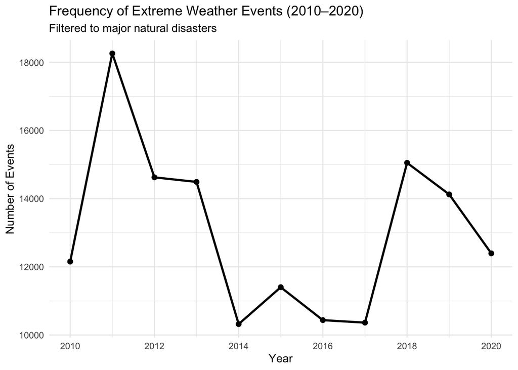

```r
ggplot(storms_by_year, aes(x = BEGIN_YEAR, y = n_events)) +
  geom_line(linewidth = 1) +
  geom_point(size = 2) +
  labs(
    title = "Frequency of Extreme Weather Events (2010–2020)",
    subtitle = "Filtered to major natural disasters",
    x = "Year",
    y = "Number of Events"
  ) +
  theme_minimal() +
  scale_x_continuous(breaks = c(2010,2012,2014,2016,2018,2020))
```

### Plot 2: Frequency of storms and fatalities by year

Since there was no strong trend in the total number of storms, next we wanted to see if there was any increase in the total number of fatalities, injuries, or damage cost. We assumed this could be a metric for the severity of the storms. However, there was no strong trend in this either.

#### Data cleaning for Plot 2

First, we sum the indirect and direct injuries and deaths into one column, casualties, and merge that data frame with the storms by year dataset.

```r
storms_by_year <- storms |>
  count(BEGIN_YEAR, name = "n_events")

storm_casualties <- storms |>
  rowwise(EVENT_ID) |>
  mutate(CASUALTIES = sum(c(INJURIES_DIRECT, INJURIES_INDIRECT, DEATHS_DIRECT, DEATHS_INDIRECT))) |>
  group_by(BEGIN_YEAR) |>
  summarise(casualties_year = sum(CASUALTIES))
```

```r
casualties_storms <- left_join(storm_casualties, storms_by_year)
```

To add in the total damage cost, we must reformat the way the cost is written. In the dataset, cost is abbreviated with K for thousand, and values with no damage are a mix between 0.00K and NA. Here, we rewrite the cost to a usable format and set all NA and 0.00K values to 0. Then, we join the casualty and cost dataframes.

```r
#Replace NA with 0
storm_damages <- storms |>
  mutate(
    #convert crops damage
    CROPS_NUM = case_when(
      grepl("B", DAMAGE_CROPS, ignore.case = TRUE) ~ as.numeric(gsub("[B]", "", DAMAGE_CROPS, ignore.case = TRUE)) * 1e9 / 1e7,
      grepl("M", DAMAGE_CROPS, ignore.case = TRUE) ~ as.numeric(gsub("[M]", "", DAMAGE_CROPS, ignore.case = TRUE)) * 1e6 / 1e7,
      grepl("K", DAMAGE_CROPS, ignore.case = TRUE) ~ as.numeric(gsub("[K]", "", DAMAGE_CROPS, ignore.case = TRUE)) * 1e3) / 1e7,
    #convert property damage
    PROP_NUM = case_when(
      grepl("B", DAMAGE_PROPERTY, ignore.case = TRUE) ~ as.numeric(gsub("[B]", "", DAMAGE_PROPERTY, ignore.case = TRUE)) * 1e9 / 1e7,
      grepl("M", DAMAGE_PROPERTY, ignore.case = TRUE) ~ as.numeric(gsub("[M]", "", DAMAGE_PROPERTY, ignore.case = TRUE)) * 1e6 / 1e7,
      grepl("K", DAMAGE_PROPERTY, ignore.case = TRUE) ~ as.numeric(gsub("[K]", "", DAMAGE_PROPERTY, ignore.case = TRUE)) * 1e3 / 1e7)) |>

select(BEGIN_YEAR, CROPS_NUM, PROP_NUM, DAMAGE_PROPERTY, DAMAGE_CROPS, EVENT_ID)

storm_damages$PROP_NUM[is.na(storm_damages$PROP_NUM)] <- 0
storm_damages$CROPS_NUM[is.na(storm_damages$CROPS_NUM)] <- 0
```

```r
#Find total damage cost per year
storm_damages <- storm_damages |>
  rowwise(EVENT_ID) |>
  mutate(DAMAGES = sum(c(PROP_NUM, CROPS_NUM))) |>
  group_by(BEGIN_YEAR) |>
  summarise(damage_year = sum(DAMAGES))

casualties_storms <- left_join(casualties_storms, storm_damages)
```

#### Final Plot 2

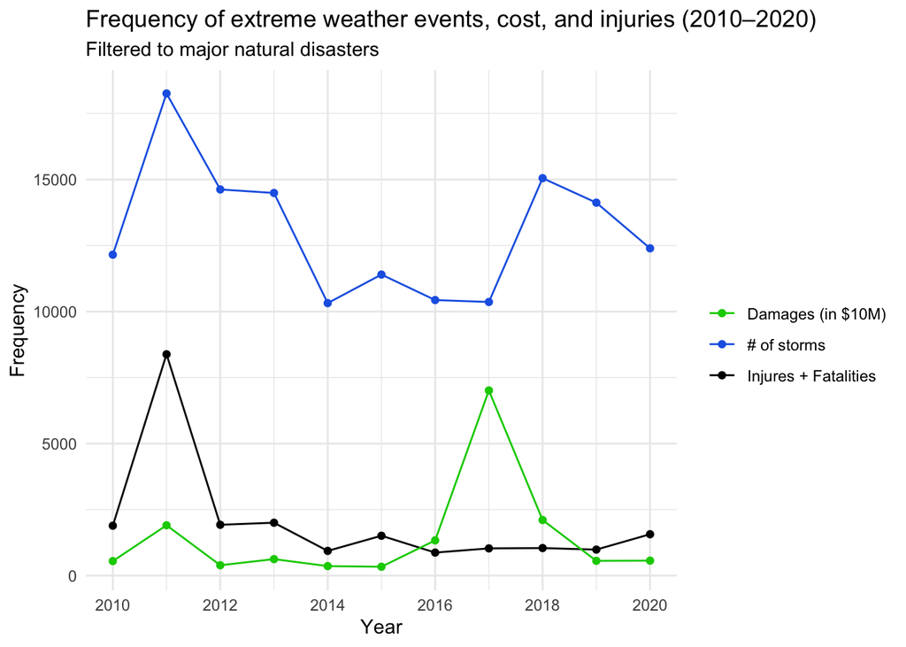

```r
ggplot(casualties_storms, aes(BEGIN_YEAR)) +
  geom_line(aes(y = n_events, color = "orange")) +
  geom_line(aes(y = casualties_year, color = "red")) +
  geom_line(aes(y = damage_year, color = "green")) +
  geom_point(aes(y = n_events, color = "orange")) +
  geom_point(aes(y = casualties_year, color = "red")) +
  geom_point(aes(y = damage_year, color = "green")) +
  labs(
    title = "Frequency of extreme weather events, cost, and injuries (2010–2020)",
    subtitle = "Filtered to major natural disasters",
    x = "Year",
    y = "Frequency",
    color = ""
  ) +
  theme_minimal() +
  scale_color_manual(
    values = c("orange" = "#1f66e5", "red" = "black", "green" = "#00cd00"),
    labels = c("orange" = "# of storms",
               "red" = "Injures + Fatalities",
               "green" = "Damages (in $10M)")) +
  scale_x_continuous(breaks = c(2010,2012,2014,2016,2018,2020))
```

### Plot 3: Final Plot 3

#### Data Cleaning for Plot 3

Here, we count the total number of events of each storm type, then plot the graph.

```r
storms_by_type_year <- storms |>
  count(BEGIN_YEAR, EVENT_TYPE, name = "n_events") |>
  filter(EVENT_TYPE %in% c("Blizzard","Drought","Flood","Flash Flood","Excessive Heat","Tornado","Tropical Storm","Wildfire"))
```

#### Final Plot 3

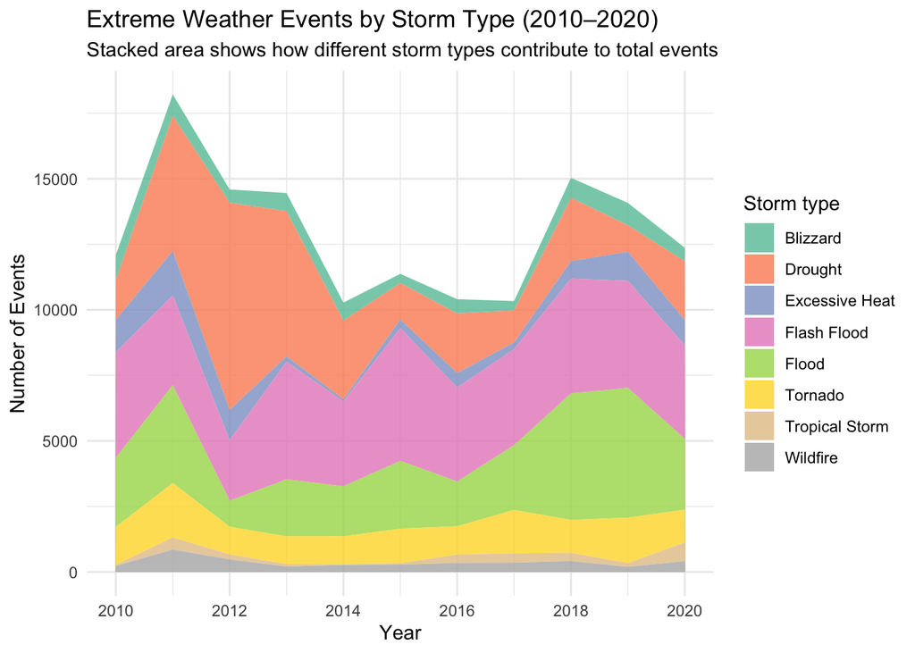

```r
ggplot(storms_by_type_year,
  aes(x = BEGIN_YEAR, y = n_events, fill = EVENT_TYPE)) +
  geom_area(alpha = 0.8, position = "stack") +
  labs(
    title = "Extreme Weather Events by Storm Type (2010–2020)",
    subtitle = "Stacked area shows how different storm types contribute to total events",
    x = "Year",
    y = "Number of Events",
    fill = "Storm type"
  ) +
  theme_minimal() +
  scale_x_continuous(breaks = c(2010, 2012, 2014, 2016, 2018, 2020)) +
  scale_fill_brewer(palette = "Set2")
```

### Plot 4: Interactive Map of All Tornado Locations

From the previous plot, we noticed there were very consistent number of tornadoes through the years. We also had the exact location for all the tornadoes. So, we created a leaflet to take note of all the locations of these storms. However, the leaflet was not very informative which led to the creation of plot 5.

#### Plot 4

```r
map_storms <- storms |>
  filter(EVENT_TYPE %in% c("Tornado")) |>
  mutate(id = seq_len(n()))

leaflet(map_storms) |>
  addProviderTiles(provider = providers$OpenStreetMap) |>
  addCircleMarkers(lng = ~BEGIN_LON,
                  lat = ~BEGIN_LAT,
                  popup = ~EVENT_TYPE,
                  color = "red",
                  radius = 10,
                  opacity = 0.6,
                  group = ~EVENT_TYPE,
                  clusterOptions = markerClusterOptions())
```

[interactive chart not shown]

### Plot 5: Number of Tornadoes per County

To improve on the leaflet, we wanted to see the number of tornadoes per county. So, after a lot of data cleaning and combining with the TIGRIS US Census dataset, we accomplish this. This map shows tornadoes are primarily concentrated to specific counties in the US, especially in the south and midwest.

#### Data Cleaning for Plot 5

First, we filter to just tornado, then filter to only include the relevant columns. Finally, we combine two location identifiers, STATE_FIPS and CZ_FIPS. Those are numeric identifiers for each state and county. On the map, there is a column called GEOID, which is the STATE_FIPS followed by the CZ_FIPS. Combining them here allows us to pinpoint exactly what county each event happened in.

```r
#Take storms, make just tornadoes, create GEOID from FIPS
T_coords <- storms |>
  filter(EVENT_TYPE == "Tornado") |>
  select(BEGIN_LAT, BEGIN_LON, STATE, STATE_FIPS, CZ_FIPS) |>
  mutate(CZ_FIPS = str_pad(CZ_FIPS, width = 3, side = "left", pad = "0")) |>
  mutate(STATE_FIPS = str_pad(STATE_FIPS, width = 2, side = "left", pad = "0")) |>
  mutate(GEOID = paste0(STATE_FIPS, CZ_FIPS))
```

Next, we download the map from the TIGRIS package, create the map df, and remove states not in the continental US.

```r
#Total tornadoes per county
tornadoes_per <- T_coords |>
  count(GEOID, name = "T_count")

#create the map
map <- map_data('county') |>
  rename(NAME = subregion)

#get data from tigris package abt counties, have GEOID and county name
geoid_df <- counties(state = NULL, cb = TRUE, progress_bar = FALSE) |>
  #remove states not in continental US
 filter(!(STATEFP %in% c("02",15,03,07,14,43,52,64,68,70,74,81,84,
                          86,67,89,71,76,95,79,60,66,69,72,78))) |>
  select(NAME, GEOID, STATEFP, STATE_NAME) |>
  mutate(NAME = tolower(NAME)) |>
  mutate(STATE_NAME = tolower(STATE_NAME)) |>
  st_drop_geometry(geoid_df)
```

Connecticut does not have counties, instead it has planning regions. The TIGIRS dataset records these planning regions, because this is what the US Census does, while the map has counties. To fix this, we rename all the counties in Connecticut, and change their GEOID as well. Also, many counties in other states have the same name so we create a new column with the state and county name combined.

```r
# Fix connecticut counties
geoid_df[geoid_df == "western connecticut"] <- "fairfield"
geoid_df[geoid_df == "southeastern connecticut"] <- "new london"
geoid_df[geoid_df == "naugatuck valley"] <- "new haven"
geoid_df[geoid_df == "metropolitain"] <- "fairfield"
geoid_df[geoid_df == "south central connecticut"] <- "new haven"
geoid_df[geoid_df == "lower connecticut river valley"] <- "middlesex"
geoid_df[geoid_df == "northeastern connecticut"] <- "windham"
geoid_df[geoid_df == "capitol"] <- "hartford"
geoid_df[geoid_df == "northwest hills"] <- "litchfield"

#Fix connecticut GEOID
geoid_df[geoid_df == "09110"] <- "09003"
geoid_df[geoid_df == "09120"] <- "09001"
geoid_df[geoid_df == "09130"] <- "09007"
geoid_df[geoid_df == "09140"] <- "09009"
geoid_df[geoid_df == "09150"] <- "09015"
geoid_df[geoid_df == "09160"] <- "09006"
geoid_df[geoid_df == "09170"] <- "09009"
geoid_df[geoid_df == "09180"] <- "09011"
geoid_df[geoid_df == "09190"] <- "09001"

# since some counties are combined into 1 district
geoid_df <- unique(geoid_df)

#since many counties have same name, create new state county name
map <- map |>
    mutate(CZ_ST = paste(NAME, region, sep = ","))

geoid_df <- geoid_df |>
  mutate(CZ_ST = paste(NAME, STATE_NAME, sep = ","))
```

Finally, we join the county information with the tornadoes df using their GEOID, then count the number of tornadoes per county. Then, we join this result with the original dataframe, and add this to the map dataframe. Finally we change the value for all counties with no tornadoes from NA to 0.

```r
#Joins df w/ geoid + county info with tornado locations
all_coords_geoid <- left_join(geoid_df, tornadoes_per)

# counts the number of tornadoes per county
coords_geoid <- all_coords_geoid |>
  count(GEOID, sort = TRUE)

#adds the number of tornadoes per county back to full df
all_coords_geoid <- inner_join(all_coords_geoid, coords_geoid) |>
  select(GEOID, CZ_ST, T_count)

#adds number of tornadoes to map df
map_n <- right_join(all_coords_geoid, map)


#in new df, replace NA counties with 0
map_n <- map_n |>
  mutate(T_count = ifelse(is.na(T_count), 0, T_count))
```

#### Final Plot 5: Map of Tornadoes per County

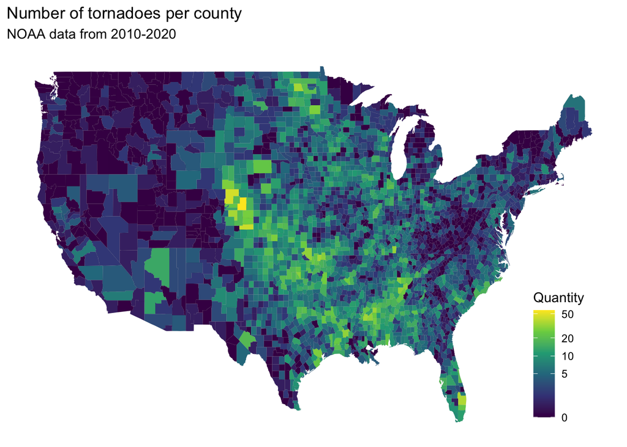

```r
#from https://jtr13.github.io/cc19/different-ways-of-plotting-u-s-map-in-r.html
ggplot(data=map_n, aes(x=long, y=lat, fill = T_count, group = group)) +
  geom_polygon(color = "black", linewidth = 0.01) +
  theme(
    legend.position = c(.9,.22),
    axis.title = element_blank(),
    axis.text = element_blank(),
    axis.ticks.x = element_blank(),
    axis.ticks.y = element_blank(),
    panel.background = element_blank(),
    panel.grid = element_blank()) +
  scale_fill_viridis_c(
    trans=scales::pseudo_log_trans(base = 10),
    breaks = c(0,5,10,20,50)
  ) +
  labs(
    title = "Number of tornadoes per county",
    fill = "Quantity",
    subtitle = "NOAA data from 2010-2020"
  )
```